# Metagenomic Analysis using Kraken part 1

Endogenomiks Scientific Team

2023-07-04

# Processing kraken reports

First, we can enter the folder containing our results, which are marked as report. We can use the code below to look at the first few lines of the report.

```bash
head $SAMPLE_OUT_REPORT
```

Using the same code, we can look at the first lines of the reports using the standard database. Can you tell the difference?

There are simple cases like this, where it is relatively easy by direct observation, to define which is a better approach based on the use of different databases. But sometimes this is not the case. Below we will make graphical representations of the results. First we will obtain graphs to help us choose the best database (of the two we are using).

## Chossing kraken database

How to choose the best database? To solve this question, it is very important to understand the biological context, the type of samples we have and finally the research question we are trying to answer. In general, having a larger number of taxonomic assignments is good news, but it could mean that we are collecting artifacts or technical contamination. In this case, we will not delve into how to deal with these types of challenges. But it is important to keep it in mind when choosing a database.

To visualize the results, first we need to process the text file, to erase all the spaces.

```r
# Read the path to the control file against the std database
Control_Std_db_file <- "path/to/your/control_file.txt"
# Read the path to the control file against the custom database
Control_custom_db_file <- "path/to/your/custom_file.txt"


#Load the content of the text file into an R variable
text_content_std <- readLines(Control_Std_db_file)
text_content_custom <- readLines(Control_custom_db_file)

# Replace two spaces with nothing
modified_content_std <- gsub("  ", "", text_content_std)
modified_content_custom <- gsub("  ", "", text_content_custom)

# Save the modified content back to the same text file
writeLines(modified_content_std, con = Control_Std_db_file)
writeLines(modified_content_custom, con = Control_custom_db_file)
```

Now that we have the results in a format without spaces, we can graphically represent our results using the following code.

#### For genus

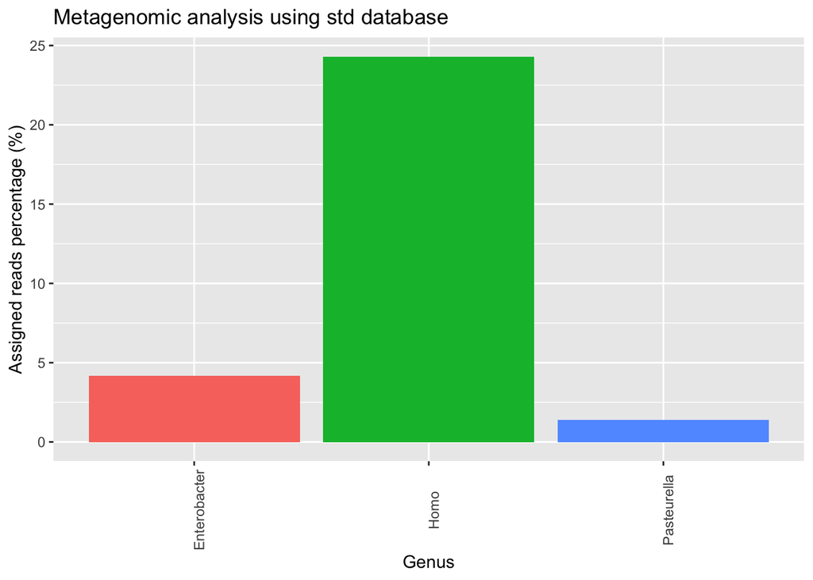

```r
#Read the reports as a dataframe
Control_Std_db <- read.csv(Control_Std_db_file,sep = "\t", header = F)
Control_custom_db <- read.csv(Control_custom_db_file,sep = "\t", header = F)

#Filter to keep only the assignments taht represent more than 1% of the reads.
Control_Std_db <- Control_Std_db[Control_Std_db$V1>1,]
Control_custom_db <- Control_custom_db[Control_custom_db$V1>1,]

#Filter to keep only the genus assignments
Control_Std_db_genus <- Control_Std_db[Control_Std_db$V4=="G",]
Control_custom_db_genus <- Control_custom_db[Control_custom_db$V4=="G",]

#We need the ggplot library to build the plot
library(ggplot2)

ggplot(Control_Std_db_genus, aes(x=V6, y=V1,fill=V6)) +
  geom_bar(stat='identity', position='dodge') +
  theme(axis.text.x = element_text(angle=90))+
  labs(title="Metagenomic analysis using std database",
        x ="Genus", y = "Assigned reads percentage (%)")+
  guides(fill="none")
```

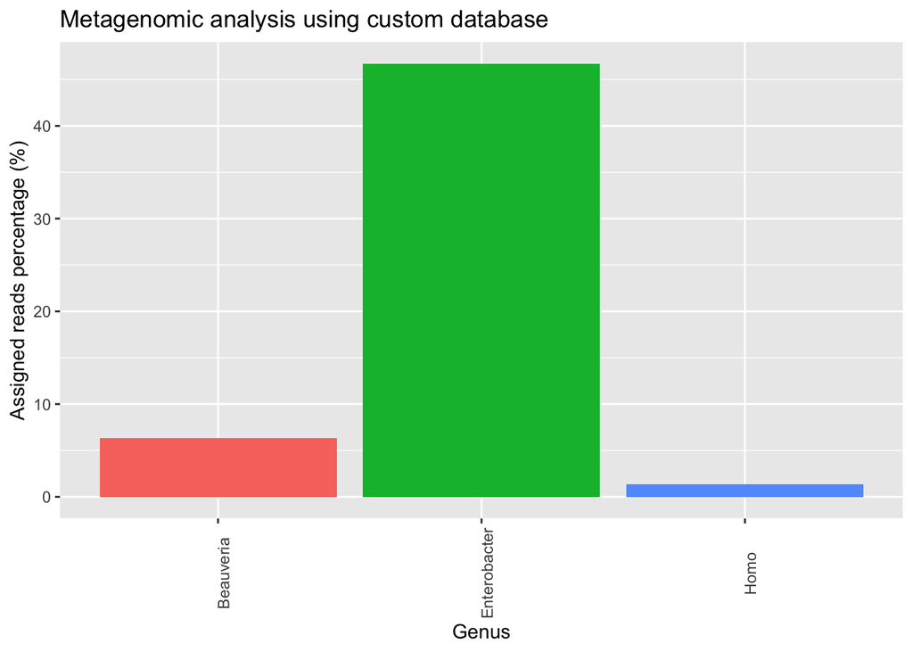

```r
ggplot(Control_custom_db_genus, aes(x=V6, y=V1,fill=V6)) +
  geom_bar(stat='identity', position='dodge') +
  theme(axis.text.x = element_text(angle=90))+
  labs(title="Metagenomic analysis using custom database",
        x ="Genus", y = "Assigned reads percentage (%)")+
  guides(fill="none")
```

### For species

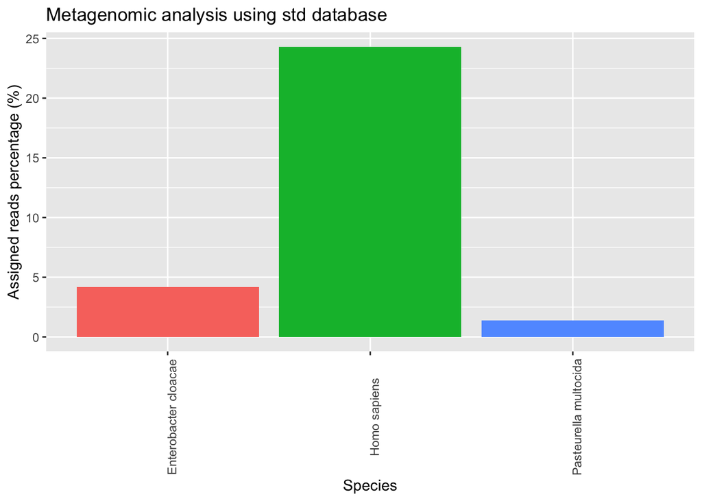

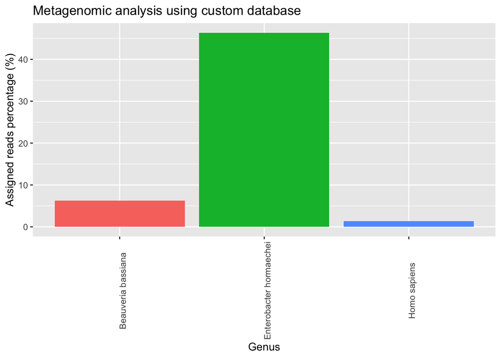

A good strategy is to put the numbers in per cent above the bars. This can be accomplished by creating a new column using the following code, you can play with all the reports to get this representation.

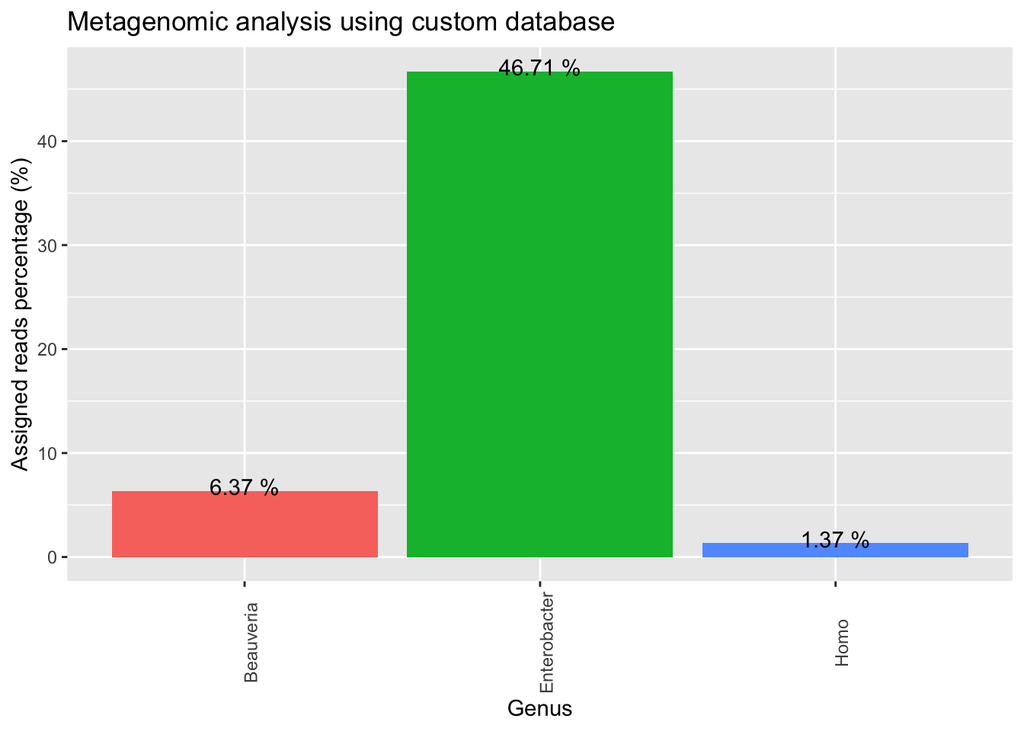

```r
Control_custom_db_genus$label <- paste(Control_custom_db_genus$V6, Control_custom_db_genus$V1, sep = "\n")
Control_custom_db_genus$label <- paste(Control_custom_db_genus$label,"%")
Control_custom_db_genus$percen <- paste(Control_custom_db_genus$V1,"%")


ggplot(Control_custom_db_genus, aes(x=V6, y=V1,fill=V6)) +
       geom_bar(stat='identity', position='dodge') +
  geom_text(aes(label=percen), position=position_dodge(width=1),angle=00,vjust = 0.25)+
  theme(axis.text.x = element_text(angle=90))+
  labs(title="Metagenomic analysis using custom database",
        x ="Genus", y = "Assigned reads percentage (%)")+
  guides(fill="none")
```

## Comparing diferent datasets

**How our dataset was build?**: As a reminder, I added some info about the dataset at the bottom of this page

Finally, we can perform the same process to compare the different biological samples we obtained.

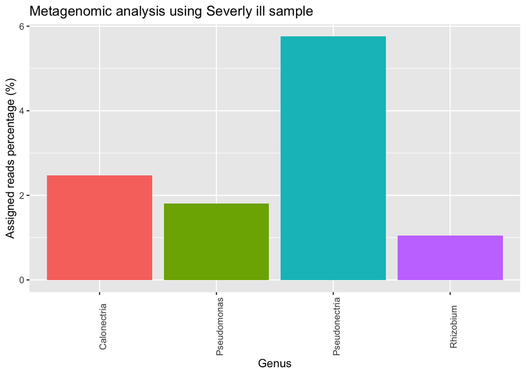

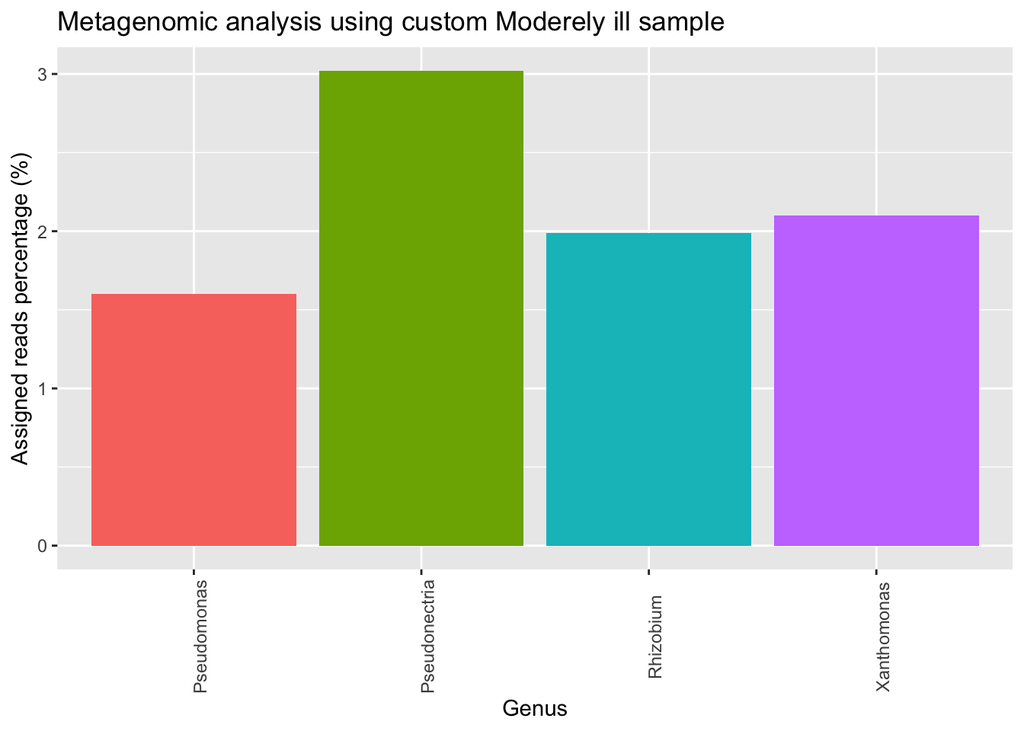

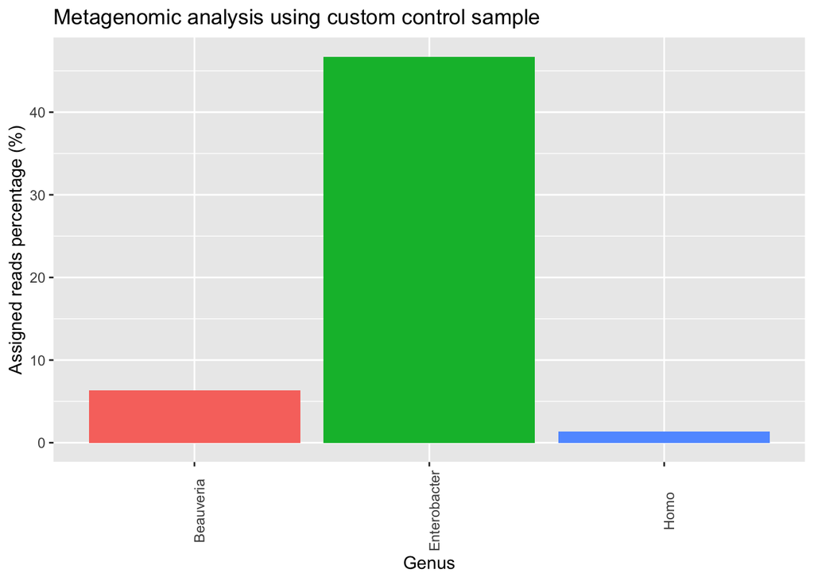

### Dataset

The sooner a disease outbreak is detected and the causative agent is identified, the faster the outbreak can be controlled by implementing testing, quarantine, and isolation. This applies to human, animal, and plant diseases. Boxwood blight is a devastating fungal plant disease of ornamentals in the Buxaceae family including boxwood (Buxus spp.), sweet box (Sarcococca spp.), and pachysandra (Pachysandra spp.). Because boxwood is one of the most popular horticultural crops in the U.S. with annual sales of $126 million, boxwood blight has caused significant economic losses and is of great concern to the landscape and nursery industry and home growers. The disease is caused by two closely related fungal species, Calonectria pseudonaviculata (Cps) and Calonectria henricotiae (Che). We have three samples coming from severly ill plants, modereely ill plants and the control.